Skip to book

# Welcome, game maker!

LEARN BY MAKING

JavaScript Game Programming for Kids

**Hung-Fu Chang, Ph.D. and Wenhui Zhu, Ph.D.**

Build a game. Understand the code. Make it your own. Explore 2D and 3D.

18 chapters Visual explanations Advanced Study

This book teaches JavaScript in the order a young game designer needs it. Instead of memorizing programming rules first, you will meet a problem inside a game and learn the programming idea that solves it.

The rule of this book

Make something move. Make something react. Make something fun. Then study the code that made it happen.

## Choose your reading path

Follow the main explanations and code examples first. Use the diagrams to trace what the program is doing. Then try a challenge and explain your result in your own words.

Chapters 1-10 establish the foundations. Chapters 11-14 build a complete 2D adventure. Chapters 15-18 introduce Three.js, custom 3D models, and Rapier physics. The later projects take more time and combine earlier ideas; work through them in small experiments.

Purple **Advanced Study** blocks are optional deeper dives into HTML, CSS, JavaScript, and game systems. They start open; you can collapse them while following the main path and return later.

**Understand**

Blue blocks introduce the big idea.

**Build**

Green blocks hold your mission and challenges.

**Go deeper**

Purple blocks explain what happens underneath.

**Explain**

Rose blocks help you check your understanding.

## What you need

- A modern web browser such as Chrome, Edge, Firefox, or Safari.
- A plain-text code editor available on your computer.
- A folder for each game containing an HTML file. Early examples keep HTML and JavaScript together so you can focus on the programming ideas.

Start with one file

Create a folder named `my-first-game`. Save your complete HTML example as `index.html`, not `index.html.txt`. Open it in your browser. After editing, save the file and refresh the browser. Later, module-based projects need a local development server.

## Read examples carefully

A **complete example** includes the setup for that small project. A **code fragment** illustrates one part of a game and relies on the variables or functions discussed nearby. Do not paste every fragment into one file without checking where it belongs: some examples replace earlier versions.

Chapters 7-9 use Pong, Breakout, and Snake to explain larger game-building patterns. Their snippets are building blocks rather than full finished games. Chapters 11-18 add complete companion projects in the Game Lab. Their chapter snippets explain selected parts; the linked project folders contain the complete runnable source.

## A safe learning habit

When a program does not work, do not immediately replace it with someone else’s code. Read the browser console, compare one small section at a time, and explain what you expected to happen. Debugging is part of programming, not evidence that you failed.

## Your game-making journey

| Chapter | Game | Coding ideas | Your new ability |
| --- | --- | --- | --- |
| 1 | Click the Monster | Events, functions | Make code react to a click |
| 2 | Treasure Clicker | Variables, text updates | Make the game remember |
| 3 | Secret Number | Input, if/else | Make the game choose |
| 4 | Rock Paper Scissors | Functions, random numbers | Package behavior into reusable actions |
| 5 | Catch the Star | Timers, coordinates, DOM | Change the page over time |
| 6 | Bouncing Ball | Canvas, animation | Draw every frame yourself |
| 7 | Pong | Keyboard, game loop | Read keys while the game keeps running |
| 8 | Breakout | Arrays, collision | Manage many objects |
| 9 | Snake | Grid logic, state | Update a world one step at a time |
| 10 | Game Studio | Planning, polish, final project | Design your own rules |
| 11 | Collision Playground | Input, velocity, fixed steps | Build a predictable real-time loop |
| 12 | Platforms and jumping | Hitboxes, collision response, gravity | Stop at walls and land on platforms |
| 13 | Your own 2D artwork | Sprite sheets, loading, JSON levels | Make the game look like your design |
| 14 | Robot Orchard | Scrolling, enemies, goals, restart | Finish a complete 2D adventure |
| 15 | Robot Island Explorer | Scene, camera, renderer, 3D movement | Build and explore a 3D world |
| 16 | 3D Asset Workshop | GLB models, origins, materials | Customize and import 3D artwork |
| 17 | Rapier Drop Lab | Bodies, colliders, bounce, fixed steps | Connect physics to the picture |
| 18 | Marble Quest | Forces, sensors, scoring, respawn | Finish a 3D physics game |

## Open the Game Lab

The companion Game Lab contains six complete projects, including two experimental labs, two collectible adventures, a 3D exploration game, and a model-customization workshop. Keep the project folders together so their shared code and assets can be found.

Run the later projects

From the extracted textbook folder, run `node scripts/serve.mjs`. Open `http://127.0.0.1:8000/games/` in your browser. This local server needs Node.js but no package installation. Use the Game Lab guide for controls, file locations, and troubleshooting.

The 2D projects use local files only. The 3D projects initially download pinned Three.js and Rapier modules from a CDN, so they need an internet connection and a browser with WebGL2. An optional dependency-download script supports later offline use.

# 1 Make the Page React

GAME 01 | Click the Monster

Events Functions HTML

Your mission

By the end of this chapter, you can:

- connect JavaScript to a button
- write and call a function
- respond to a click event

The big idea

A game begins when the player does something and the program reacts. In the browser, those actions are called events.

## 1.1 Your first game screen

We will start with one HTML file. The button is our monster. When the player clicks it, JavaScript runs a function.

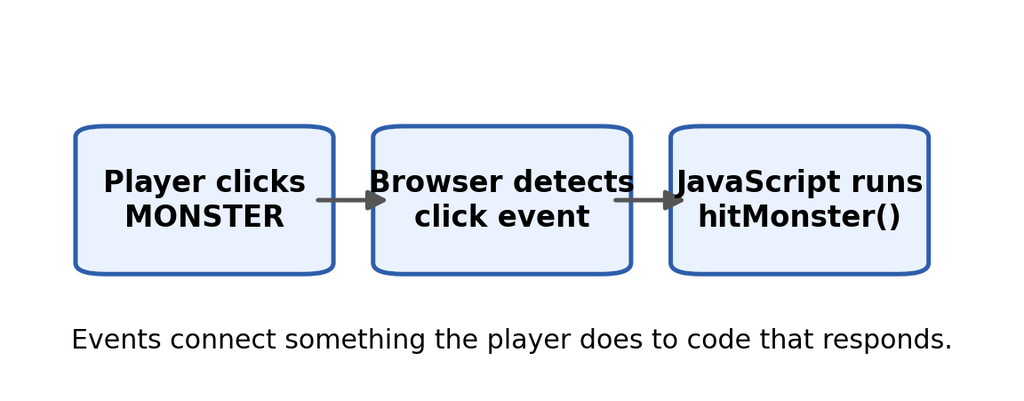

Event flow: a player action becomes a JavaScript response.

**Read the picture:** Follow the arrows from left to right. The player creates the event; the browser notices it; the registered function supplies the response. Registering a listener does not run the function immediately.

```html
<!doctype html>
<html>
<body>
  <h1>Click the Monster!</h1>
  <button id="monster">👾 Monster</button>
  <script>
    // JavaScript goes here
  </script>
</body>
</html>
```

## 1.2 A function is an action you can name

A function groups instructions. The function below has a name: `hitMonster`. Nothing inside it runs until the function is called.

```javascript
function hitMonster() {
  alert("You hit the monster!");
}
```

## 1.3 Connect the click to the function

The browser can listen for events. `addEventListener` tells an element what kind of event to watch for and which function should run.

```javascript
const monster = document.getElementById("monster");
monster.addEventListener("click", hitMonster);
```

## 1.4 Build the complete game

Put the pieces together. Type the code yourself if you can; typing helps your brain notice punctuation, spelling, and structure.

COMPLETE EXAMPLE

```html
<!doctype html>
<html>
<body>
  <h1>Click the Monster!</h1>
  <button id="monster">👾 Monster</button>
  <p id="message">Can you catch it?</p>

  <script>
    const monster = document.getElementById("monster");
    const message = document.getElementById("message");

    function hitMonster() {
      message.textContent = "Great hit!";
    }

    monster.addEventListener("click", hitMonster);
  </script>
</body>
</html>
```

Advanced Study | HTML elements and the DOM

OPTIONAL DEEPER DIVE

HTML gives the browser a structure. JavaScript does not usually change the HTML file itself while the game is running; it changes the browser’s in-memory representation called the DOM. `getElementById()` returns one DOM element, and `addEventListener()` attaches behavior without mixing JavaScript directly into the HTML tag.

```javascript
const monster = document.getElementById('monster');
monster.addEventListener('click', hitMonster);
```

**HTML and JavaScript have different jobs.** In `<button id="monster">Monster</button>`, `button` identifies the kind of element, `id` gives it a unique name on this page, and the text between the tags becomes its label. The JavaScript lookup must match that ID exactly.

**Why is the script at the bottom?** The browser reaches the button before the script tries to find it. Keep that order. If the lookup finds nothing, it returns `null`.

**Function name or function call?** Pass `hitMonster` to the listener so the browser can call it later. Writing `hitMonster()` calls it immediately.

## 1.5 Level-up challenges

Challenge 1

Change the monster button into a dragon or robot.

Challenge 2

Add a second button with a different function and message.

# 2 Teach the Game to Remember

GAME 02 | Treasure Clicker

Variables Strings DOM

Your mission

By the end of this chapter, you can:

- create variables with let and `const`
- change a variable
- show a value on the page

The big idea

A score is memory. The game needs a place to store a number and change it after each successful action.

## 2.1 Variables are labeled storage

Use let when a value will change. Use `const` when the variable should keep referring to the same thing.

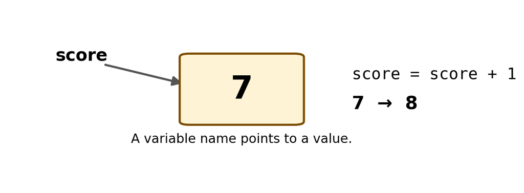

A variable is a named place for a value that can change.

**Read the picture:** First read the old value, 7. Add 1 to get 8. Finally, assign 8 back to `score`. The label stays the same while the value changes.

```javascript
let score = 0;
const treasure = document.getElementById("treasure");
```

## 2.2 Updating the score

The assignment operator = stores a new value. `score = score + 1` means: take the old score, add one, and store the result back into score.

```javascript
function collectTreasure() {
  score = score + 1;
  scoreText.textContent = "Score: " + score;
}
```

## 2.3 Strings and numbers

Text inside quotes is a string. A score such as 7 is a number. JavaScript can join text and a number with + when text is involved.

```javascript
let playerName = "Maya";
let score = 7;
message.textContent = playerName + " has " + score + " gems!";
```

## 2.4 Build the complete game

Put the pieces together. Type the code yourself if you can; typing helps your brain notice punctuation, spelling, and structure.

COMPLETE EXAMPLE

```html
<!doctype html>
<html>
<body>
  <h1>Treasure Clicker</h1>
  <button id="treasure">💎 Collect treasure</button>
  <p id="score">Score: 0</p>

  <script>
    let score = 0;
    const treasure = document.getElementById("treasure");
    const scoreText = document.getElementById("score");

    function collectTreasure() {
      score = score + 1;
      scoreText.textContent = "Score: " + score;
    }

    treasure.addEventListener("click", collectTreasure);
  </script>
</body>
</html>
```

Save the code as `index.html` and open it in your browser, or open the ready-to-run copy at `workspace/chapter2-treasure/index.html`. The score begins at zero because `let score = 0` runs when the page loads.

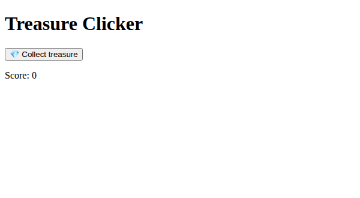

Treasure Clicker in Chrome before any clicks, showing the collect button and Score: 0.

Click the treasure button three times. Each click calls `collectTreasure()`, adds one to `score`, and puts the new number into the paragraph. The `after-three-clicks.html` companion runs those three clicks automatically so you can compare the browser result.

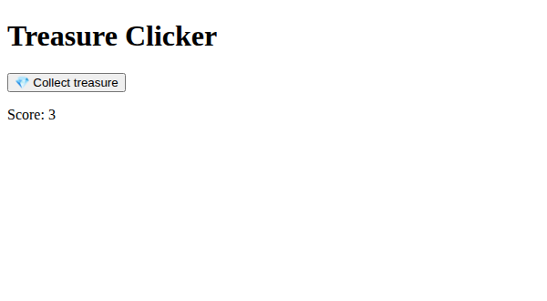

Treasure Clicker in Chrome after three clicks, showing Score: 3.

**Read the pictures:** The button and heading stay the same. The score changes from 0 to 3 because the `score` variable remembers the number between clicks, while `scoreText.textContent` shows its current value on the page. Refresh the browser to start a new game at zero.

Advanced Study | let, const, scope, and types

OPTIONAL DEEPER DIVE

Use `const` when a name should not be reassigned and let when the stored value needs to change. JavaScript is dynamically typed: a variable is not permanently locked to one type. For beginning games, keep each variable consistent—scores stay numbers, names stay strings, and element references stay DOM objects.

```javascript
let score = 0;
const scoreLabel = document.getElementById('score');
scoreLabel.textContent = score;
```

**A constant is not a frozen object.** `const scoreLabel` keeps the same element reference, but `scoreLabel.textContent` can still change. What cannot change is which element the name refers to.

**Scope means where a name is available.** A `let` or `const` declared inside block braces is available within that block, not everywhere. Our score lives outside the click function so repeated clicks share it.

**Predict before running:** How do `7 + 1` and `"7" + 1` differ? The first adds numbers; the second joins text.

## 2.5 Level-up challenges

Challenge 1

Make each treasure worth 5 points.

Challenge 2

Add a “spend 10 points” button. Only worry about subtracting for now; Chapter 3 will teach you how to prevent negative scores.

# 3 Let the Game Make Decisions

GAME 03 | Secret Number

Input Decisions Comparisons

Your mission

By the end of this chapter, you can:

- read a player value
- compare values
- use if, `else if`, and `else`

The big idea

Games constantly ask questions: Did the player touch the enemy? Is the timer finished? Is this guess too high? An if statement lets code choose what happens next.

## 3.1 Read input

The value property reads what a player typed. `Number(...)` converts text such as “7” into the number 7.

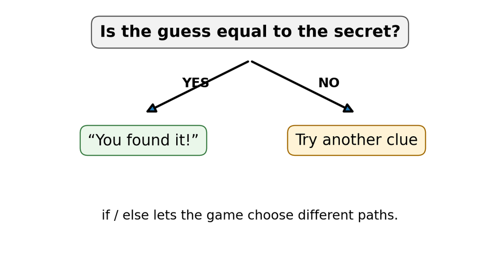

Decision flow: conditions choose which code path runs.

**Read the picture:** A condition chooses one path. In our game, the first check is equality. Only when it is false do the later checks decide between too low and too high.

```javascript
const guessBox = document.getElementById("guess");
const guess = Number(guessBox.value);
```

## 3.2 Ask a yes/no question

A comparison produces `true` or `false`. `===` asks whether two values are equal in both value and type.

```javascript
if (guess === secret) {
  message.textContent = "You found it!";
}
```

## 3.3 More than two choices

`else if` lets the program check another condition when the first one was `false`.

```javascript
if (guess === secret) {
  message.textContent = "Correct!";
} else if (guess < secret) {
  message.textContent = "Too low!";
} else {
  message.textContent = "Too high!";
}
```

## 3.4 Build the complete game

Put the pieces together. Type the code yourself if you can; typing helps your brain notice punctuation, spelling, and structure.

COMPLETE EXAMPLE

```html
<!doctype html>
<html>
<body>
  <h1>Secret Number</h1>
  <input id="guess" type="number" min="1" max="10">
  <button id="check">Check</button>
  <p id="message">Guess a number from 1 to 10.</p>

  <script>
    const secret = Math.floor(Math.random() * 10) + 1;
    const guessBox = document.getElementById("guess");
    const message = document.getElementById("message");

    document.getElementById("check").addEventListener("click", function () {
      const guess = Number(guessBox.value);
      if (guess === secret) {
        message.textContent = "Correct!";
      } else if (guess < secret) {
        message.textContent = "Too low!";
      } else {
        message.textContent = "Too high!";
      }
    });
  </script>
</body>
</html>
```

Open the ready-to-run game at `workspace/chapter3-secret-number/index.html`, or save the code above as `index.html` and open it in your browser. The game chooses a new secret from 1 to 10 each time the page loads. To show all three paths in the screenshots, the companion demo pages use a fixed secret of 6 and enter one guess automatically.

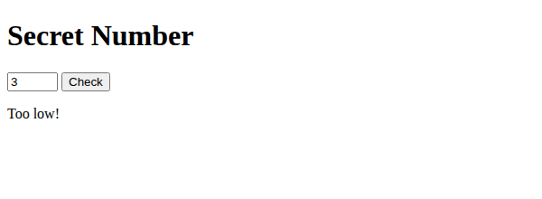

Secret Number in Chrome after guessing 3 when the secret is 6. The page says Too low!

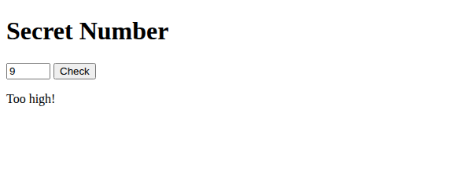

Secret Number in Chrome after guessing 9 when the secret is 6. The page says Too high!

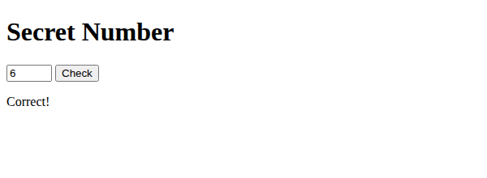

Secret Number in Chrome after guessing 6 when the secret is 6. The page says Correct!

**Read the pictures:** The same click handler runs for every guess. For 3, `guess === secret` is false and `guess < secret` is true, so the second branch says “Too low!” For 9, both checks are false, so `else` says “Too high!” For 6, the first check is true, so the game says “Correct!” and skips the other branches. Try these guesses yourself; your secret number will usually be different.

Advanced Study | How comparisons really work

OPTIONAL DEEPER DIVE

Conditions are expressions that become `true` or `false`. Prefer `===` over `==` because `===` compares both value and type. `Number(input.value)` converts typed text into a number before comparison. You can combine conditions with `&&` (AND), `||` (OR), and ! (NOT).

```javascript
if (guess >= 1 && guess <= 10) {
  // valid range
}
```

**HTML constraints are not the whole game rule.** `type="number"`, `min`, and `max` describe an input and its validity constraints, but our custom click handler still needs to check the value. An empty string becomes `0` when passed to `Number()`.

For a stricter version, place this guard inside the handler before comparing with `secret`:

```javascript
const raw = guessBox.value.trim();
const guess = Number(raw);
if (raw === "" || !Number.isInteger(guess) ||
    guess < 1 || guess > 10) {
  message.textContent = "Enter a whole number from 1 to 10.";
  return;
}
```

Replace the original `const guess` line rather than declaring it twice. `return` exits this handler early.

Further reading: [MDN: number inputs and validation](https://developer.mozilla.org/en-US/docs/Web/HTML/Reference/Elements/input/number).

## 3.5 Level-up challenges

Challenge 1

Count how many guesses the player uses.

Challenge 2

Add a rule: after 5 guesses, show the secret number.

# 4 Create Reusable Game Actions

GAME 04 | Rock Paper Scissors

Parameters Return values Randomness

How to use the code pieces

Your mission

By the end of this chapter, you can:

- use function parameters and return values
- generate a random choice
- break a problem into small functions

The big idea

As games grow, one giant function becomes difficult to understand. Small functions let us name behaviors such as `chooseComputerMove` and `decideWinner`.

## 4.1 A function can receive information

A parameter is a local name for information passed into a function.

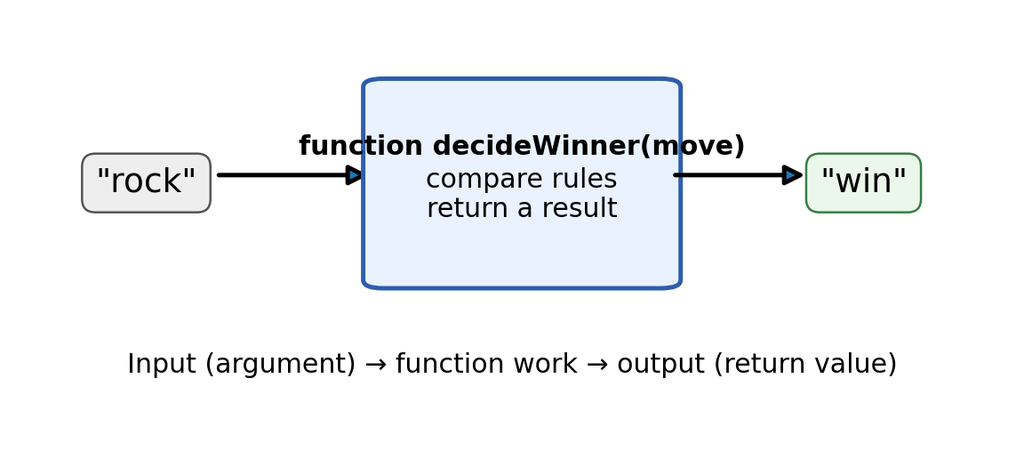

Functions can transform input into an output.

**Read the picture:** A function receives information, performs work, and may return a result. This is a simplified picture: our actual `decideWinner(player, computer)` function needs **both** moves. The player choosing rock alone does not determine a winner.

```javascript
function cheer(playerName) {
  return "Go, " + playerName + "!";
}

const message = cheer("Ari");
```

## 4.2 Make a random computer choice

`Math.random()` gives a value from 0 up to (but not including) 1. We can turn it into one of three choices.

```javascript
function computerChoice() {
  const choices = ["rock", "paper", "scissors"];
  const index = Math.floor(Math.random() * 3);
  return choices[index];
}
```

## 4.3 Decide a winner

The rule function compares the player move with the computer move and returns a result.

```javascript
function decideWinner(player, computer) {
  if (player === computer) return "Tie!";

  if (
    (player === "rock" && computer === "scissors") ||
    (player === "paper" && computer === "rock") ||
    (player === "scissors" && computer === "paper")
  ) {
    return "You win!";
  }
  return "Computer wins!";
}
```

## Play the complete game in your browser

The fragments above are now assembled into one runnable page. Save this complete example as `index.html`, or open `workspace/chapter4-rock-paper-scissors/index.html`. Click Rock, Paper, or Scissors to play a round. `playRound(player)` passes your move to `decideWinner(player, computer)` and puts its returned result on the page.

COMPLETE EXAMPLE | `index.html`

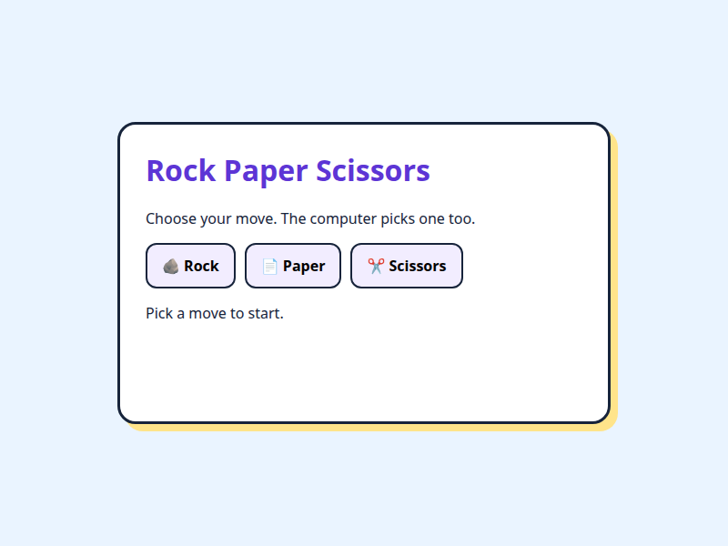

Rock Paper Scissors in Chrome before a move. Three buttons offer rock, paper, and scissors.

```html
<!doctype html>
<html lang="en">
<head>
  <meta charset="utf-8">
  <meta name="viewport" content="width=device-width, initial-scale=1">
  <title>Rock Paper Scissors</title>
  <style>
    body {
      margin: 0;
      min-height: 100vh;
      display: grid;
      place-items: center;
      background: #eaf4ff;
      color: #17243b;
      font-family: system-ui, sans-serif;
    }
    main {
      width: min(90%, 480px);
      padding: 28px;
      border: 3px solid #17243b;
      border-radius: 20px;
      background: white;
      box-shadow: 8px 8px 0 #ffe48a;
    }
    h1 { margin-top: 0; color: #5d35d5; }
    .choices { display: flex; flex-wrap: wrap; gap: 10px; }
    button {
      padding: 12px 16px;
      border: 2px solid #17243b;
      border-radius: 12px;
      background: #f2edff;
      font: inherit;
      font-weight: 700;
      cursor: pointer;
    }
    button:hover, button:focus-visible { background: #dfd1ff; }
    #round, #result { min-height: 1.5em; }
    #result { font-size: 1.4rem; font-weight: 800; }
  </style>
</head>
<body>
  <main>
    <h1>Rock Paper Scissors</h1>
    <p>Choose your move. The computer picks one too.</p>
    <div class="choices">
      <button type="button" data-move="rock">🪨 Rock</button>
      <button type="button" data-move="paper">📄 Paper</button>
      <button type="button" data-move="scissors">✂️ Scissors</button>
    </div>
    <p id="round" aria-live="polite">Pick a move to start.</p>
    <p id="result" aria-live="polite"></p>
  </main>
  <script>
    function computerChoice() {
      const choices = ["rock", "paper", "scissors"];
      const index = Math.floor(Math.random() * 3);
      return choices[index];
    }

    function decideWinner(player, computer) {
      if (player === computer) return "Tie!";

      if (
        (player === "rock" && computer === "scissors") ||
        (player === "paper" && computer === "rock") ||
        (player === "scissors" && computer === "paper")
      ) {
        return "You win!";
      }
      return "Computer wins!";
    }

    function playRound(player) {
      const computer = computerChoice();
      const result = decideWinner(player, computer);
      document.getElementById("round").textContent =
        "You chose " + player + ". Computer chose " + computer + ".";
      document.getElementById("result").textContent = result;
    }

    document.querySelectorAll("[data-move]").forEach(function (button) {
      button.addEventListener("click", function () {
        playRound(button.dataset.move);
      });
    });
  </script>
</body>
</html>
```

For the next three browser captures, the companion demo pages make the computer choose a known move and click Rock automatically. The regular `index.html` still uses `Math.random()` each round.

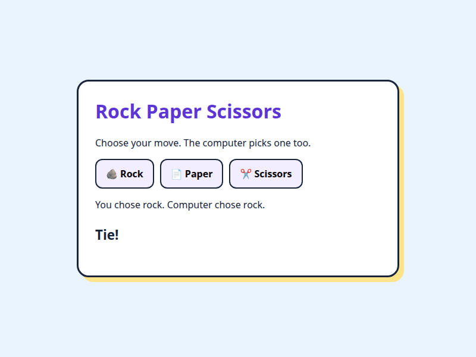

Rock Paper Scissors in Chrome when both player and computer choose rock. The result is Tie!

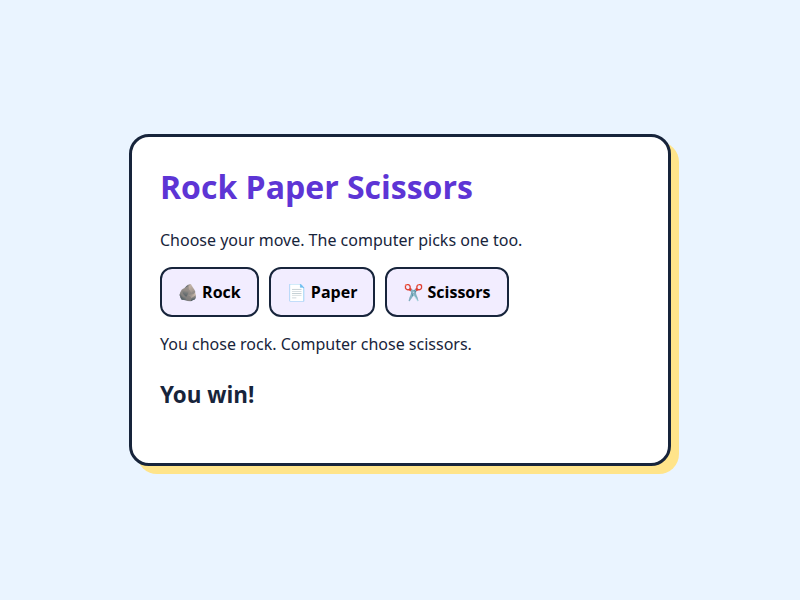

Rock Paper Scissors in Chrome when the player chooses rock and the computer chooses scissors. The result is You win!

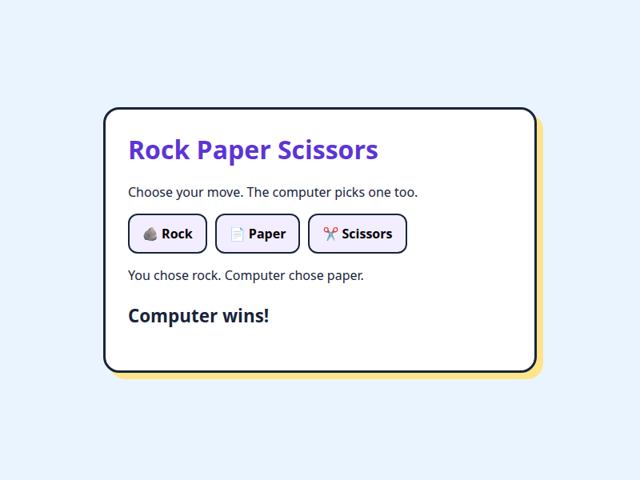

Rock Paper Scissors in Chrome when the player chooses rock and the computer chooses paper. The result is Computer wins!

**Read the pictures:** Each button gives `playRound` a player move. `computerChoice()` returns the computer move, then `decideWinner()` returns one of three result strings. Rock against rock returns “Tie!” immediately. Rock beats scissors, while paper beats rock. The caller displays the returned string in the result paragraph; `return` by itself does not change the page.

Advanced Study | Parameters, return values, and local scope

OPTIONAL DEEPER DIVE

Parameters exist only inside the function call. A return value sends information back to the caller. This makes functions easier to test because the same function can work with different inputs and produce a result instead of depending on hidden global variables.

```javascript
function beats(a, b) {
  return (a === 'rock' && b === 'scissors');
}
const result = beats('rock', 'scissors');
```

**Argument or parameter?** In `beats("rock", "scissors")`, the strings are arguments: actual values supplied to the function. Inside the function, `a` and `b` are parameter names referring to those values during this call.

**Returning is not displaying.** `return` sends a value to the caller and ends this function call. The caller chooses whether to save it, display it, or use it in another decision.

The small `beats` example checks only rock against scissors. Use `decideWinner` for the complete three-move rules.

## 4.4 Level-up challenges

Challenge 1

Add emoji to the result message.

Challenge 2

Track player wins and computer wins.

Challenge 3

Invent a fourth move and decide what it beats. Notice how the rule logic becomes more complicated.

# 5 Make Things Change Over Time

GAME 05 | Catch the Star

Timers Coordinates CSS

Your mission

By the end of this chapter, you can:

- use CSS position values from JavaScript
- use random coordinates
- use `setInterval` and `clearInterval`

The big idea

A moving game world changes even when the player is not clicking. Timers let JavaScript run an action again and again.

## 5.1 Move an element

An absolutely positioned element can be moved by changing its left and top CSS properties.

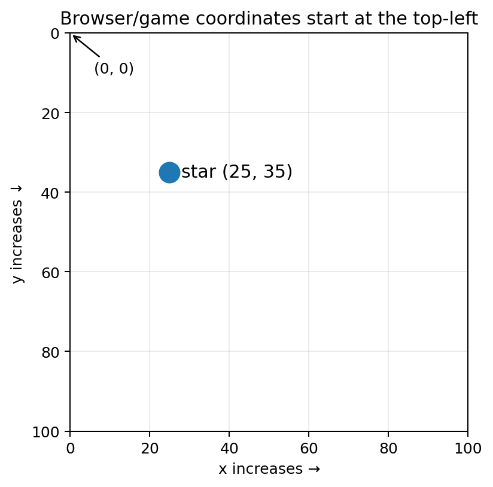

Game coordinates: x moves right, y moves down.

**Read the picture:** Start at the top-left corner. Move 25 units right and 35 units down to reach the star. These are example coordinates, not fixed limits for your game; use the size of your own game area.

```javascript
star.style.left = "120px";
star.style.top = "80px";
```

## 5.2 Pick a random position

A helper function makes the star jump to a new place.

```javascript
function moveStar() {
  const x = Math.floor(Math.random() * 280);
  const y = Math.floor(Math.random() * 180);
  star.style.left = x + "px";
  star.style.top = y + "px";
}
```

## 5.3 Repeat an action with a timer

`setInterval` calls a function repeatedly. The number is milliseconds, so 1000 means one second.

```javascript
const timerId = setInterval(moveStar, 1000);

// Later, when the game ends:
clearInterval(timerId);
```

## 5.4 Build the complete game

Put the pieces together. Type the code yourself if you can; typing helps your brain notice punctuation, spelling, and structure.

COMPLETE EXAMPLE

```html
<!doctype html>
<html>
<head>
<style>
  #game { position: relative; width: 340px; height: 240px; border: 2px solid #333; }
  #star { position: absolute; font-size: 36px; cursor: pointer; }
</style>
</head>
<body>
  <h1>Catch the Star</h1>
  <p id="score">Score: 0</p>
  <div id="game"><span id="star">⭐</span></div>
<script>
  let score = 0;
  const star = document.getElementById("star");
  const scoreText = document.getElementById("score");

  function moveStar() {
    const x = Math.floor(Math.random() * 280);
    const y = Math.floor(Math.random() * 180);
    star.style.left = x + "px";
    star.style.top = y + "px";
  }

  star.addEventListener("click", function () {
    score++;
    scoreText.textContent = "Score: " + score;
    moveStar();
  });

  moveStar();
  setInterval(moveStar, 1000);
</script>
</body>
</html>
```

Open the runnable copy at `workspace/chapter5-catch-the-star/index.html`, or save the code above as `index.html` and open it in a browser. The real game calls `moveStar()` at the start and once every second. Clicking the star adds one point and moves it immediately.

For the browser screenshots, the companion demonstration pages use known random values. `demo-start.html` pauses the timer, `demo-after-timer.html` runs one scheduled move, and `demo-after-click.html` runs one scheduled move and one click. This makes each state easy to compare; the regular game still uses its one-second timer.

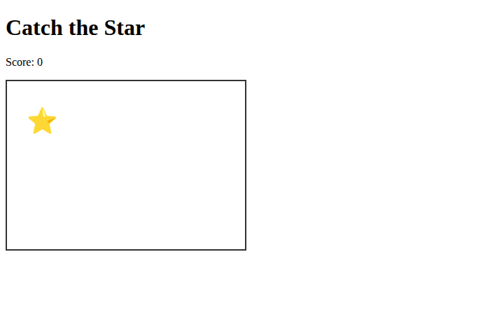

Catch the Star in Chrome at score zero, with the star near the upper left of the game area.

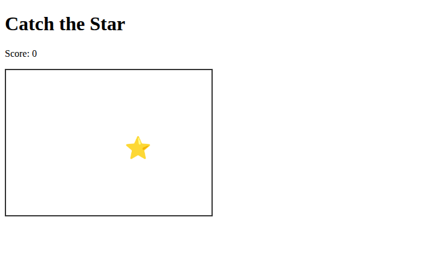

Catch the Star in Chrome after one timer move. The star is farther right and lower, while the score stays zero.

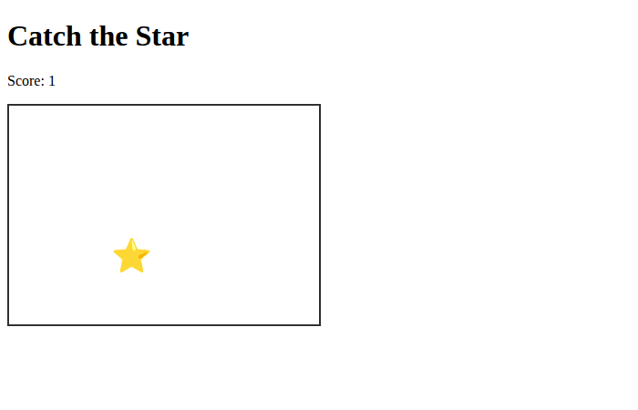

Catch the Star in Chrome after a click. The score is one and the star has moved again.

**Read the pictures:** The timer calls `moveStar()` even when the player does nothing, so the star changes position while the score stays at zero. The click handler changes `score` from 0 to 1, updates the paragraph, and calls `moveStar()` again. Each new `left` and `top` value places the star inside the bordered game area.

Advanced Study | CSS positioning and browser coordinates

OPTIONAL DEEPER DIVE

For positioned HTML elements, left controls horizontal position and top controls vertical position. In browser coordinates, (0,0) is normally the top-left of the containing area, x increases to the right, and y increases downward. Element sizes matter when keeping an object inside the game area.

```javascript
star.style.left = x + 'px';
star.style.top = y + 'px';
```

**Which box do the coordinates belong to?** `#game { position: relative; }` makes the game area the containing block for the absolutely positioned star. Its offsets are measured from that area, not automatically from the entire page.

**Keep the whole object inside.** The largest useful x offset is approximately the game width minus the star width. The same idea applies to height.

**One timer is enough.** Keep the ID returned by `setInterval()` when you need to stop or replace it. Clearing a timer stops scheduled moves, not the separate click listener.

## 5.5 Level-up challenges

Challenge 1

Make the star move faster after the player reaches 5 points.

Challenge 2

Add a 20-second countdown and stop the game when time reaches zero.

# 6 Draw Your Own Game World

GAME 06 | Bouncing Ball

Canvas Animation Velocity

Your mission

By the end of this chapter, you can:

- create a canvas
- draw shapes with a 2D context
- animate with `requestAnimationFrame`

The big idea

Canvas is different from ordinary HTML. Instead of moving page elements, your code redraws the game world frame after frame.

## 6.1 Meet canvas

The canvas element is a rectangular drawing surface. JavaScript asks it for a 2D drawing context.

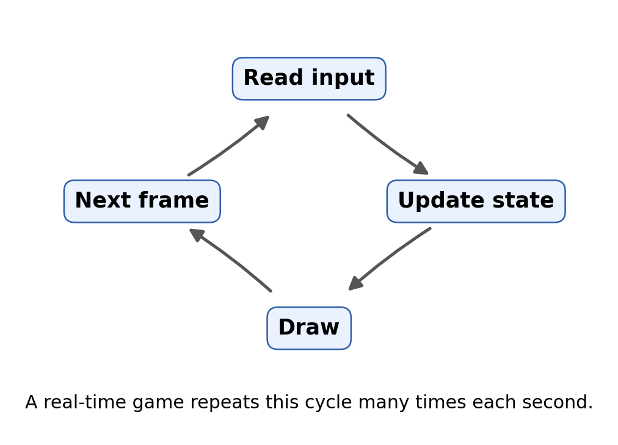

The animation/game loop repeats update and draw work.

**Read the picture:** Each frame is one trip around the cycle. Bouncing Ball has no keyboard input yet, so it begins by updating position. The next chapter adds player input before movement.

```javascript
const canvas = document.getElementById("game");
const ctx = canvas.getContext("2d");
```

## 6.2 Draw a ball

A circle is an arc that goes all the way around.

```javascript
ctx.beginPath();
ctx.arc(x, y, 15, 0, Math.PI * 2);
ctx.fill();
```

## 6.3 Animation is update + draw + repeat

Each frame changes the position, clears the old picture, draws the new picture, and asks the browser for another frame.

```javascript
function loop() {
  x = x + dx;
  y = y + dy;

  ctx.clearRect(0, 0, canvas.width, canvas.height);
  drawBall();

  requestAnimationFrame(loop);
}
```

## 6.4 Bounce at the edges

Reverse a velocity when the ball reaches a wall.

```javascript
if (x < radius || x > canvas.width - radius) {
  dx = -dx;
}
if (y < radius || y > canvas.height - radius) {
  dy = -dy;
}
```

## 6.5 Build the complete game

Put the pieces together. Type the code yourself if you can; typing helps your brain notice punctuation, spelling, and structure.

COMPLETE EXAMPLE

```html
<!doctype html>
<html lang="en">
<head>
  <meta charset="utf-8">
  <meta name="viewport" content="width=device-width, initial-scale=1">
  <title>Bouncing Ball</title>
  <style>
    body { font-family: system-ui, sans-serif; color: #17243b; }
    canvas { border: 2px solid #17243b; background: #f0f7ff; }
  </style>
</head>
<body>
  <h1>Bouncing Ball</h1>
  <canvas id="game" width="500" height="300"></canvas>
  <script>
    const canvas = document.getElementById("game");
    const ctx = canvas.getContext("2d");
    let x = 100, y = 80;
    let dx = 3, dy = 2;
    const radius = 15;

    function drawBall() {
      ctx.beginPath();
      ctx.arc(x, y, radius, 0, Math.PI * 2);
      ctx.fillStyle = "#6d3df5";
      ctx.fill();
    }

    function loop() {
      x += dx;
      y += dy;
      if (x < radius || x > canvas.width - radius) dx = -dx;
      if (y < radius || y > canvas.height - radius) dy = -dy;
      ctx.clearRect(0, 0, canvas.width, canvas.height);
      drawBall();
      requestAnimationFrame(loop);
    }
    loop();
  </script>
</body>
</html>
```

Open `workspace/chapter6-bouncing-ball/index.html` to watch the complete example. The browser redraws the purple ball on every animation frame. The screenshot demonstration pages pause automatic frames, then call the same `loop()` function a known number of times so the positions are easy to compare.

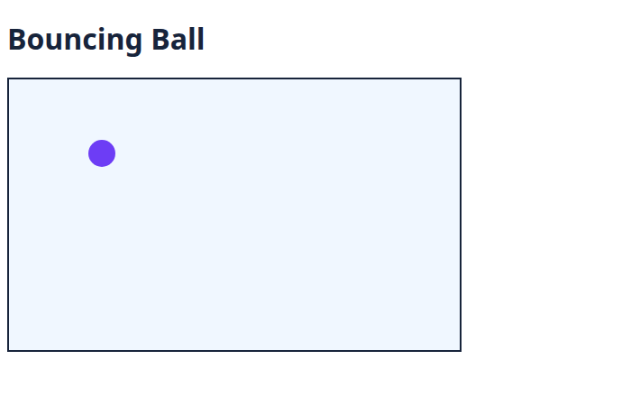

Bouncing Ball in Chrome near its starting position inside the canvas.

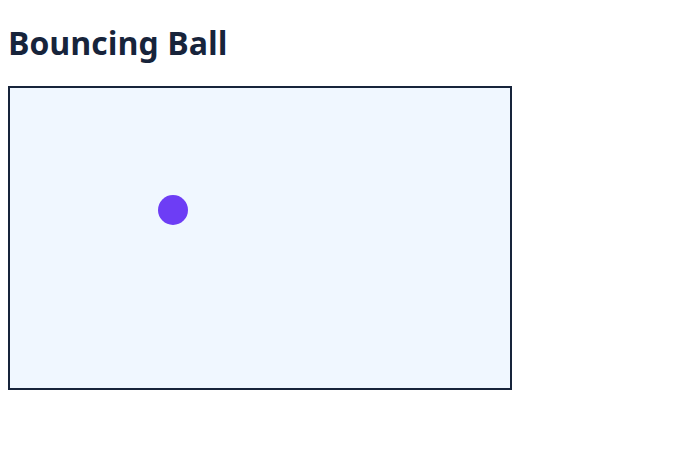

Bouncing Ball in Chrome after twenty more animation frames. The ball has moved right and down.

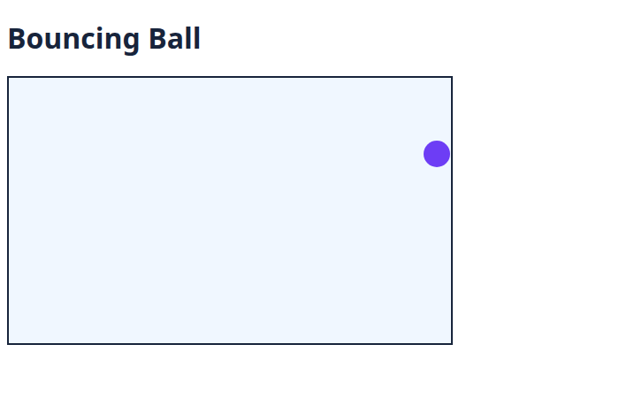

Bouncing Ball in Chrome after reaching the right wall and reversing horizontal direction.

**Read the pictures:** Each call to `loop()` adds `dx` to `x` and `dy` to `y`, clears the old drawing, then draws the ball again. At the right edge, the code changes `dx` from positive to negative, so the following frames head left. The regular page keeps requesting new frames automatically.

Advanced Study | requestAnimationFrame and frame time

OPTIONAL DEEPER DIVE

`requestAnimationFrame` asks the browser to run your animation code before the next repaint. Real games should not assume every computer draws the same number of frames per second. Advanced games use the timestamp passed to the callback to calculate delta time so motion depends on elapsed time, not frame count.

```javascript
let previousTime;
function loop(time) {
  const dt = previousTime === undefined
    ? 0
    : (time - previousTime) / 1000;
  previousTime = time;
  update(dt); // Speeds are in pixels per second.
  draw();
  requestAnimationFrame(loop);
}
requestAnimationFrame(loop);
```

**The timestamp is not the time since the last frame.** Subtract the previous timestamp and divide milliseconds by 1000 to get seconds. A speed of 180 pixels per second moves about 3 pixels in a 1/60-second frame.

This is a timing pattern, not a second loop to add beside the existing one. Supply your own `update(dt)` and `draw()` functions. Start the pattern with `requestAnimationFrame(loop)`. A more robust game should also handle a long pause, for example by resetting its previous timestamp when resuming.

Further reading: [MDN: requestAnimationFrame](https://developer.mozilla.org/en-US/docs/Web/API/Window/requestAnimationFrame).

## 6.6 Level-up challenges

Challenge 1

Change the ball speed. What values feel playable?

Challenge 2

Add a second ball with its own position and velocity.

# 7 Control a Real-Time Game

GAME 07 | Pong

Keyboard input State Collision

How to use the code pieces

The short snippets below explain individual rules. The complete browser example later in this chapter combines them into a playable page.

Your mission

By the end of this chapter, you can:

- track pressed keys
- move a paddle every frame
- detect simple rectangle/ball collisions

The big idea

In a real-time game, a key press should change what happens during the next frames. Instead of moving once per key event, we remember which keys are held down.

## 7.1 Remember key state

`keydown` sets a state to `true`. `keyup` changes it back to `false`.

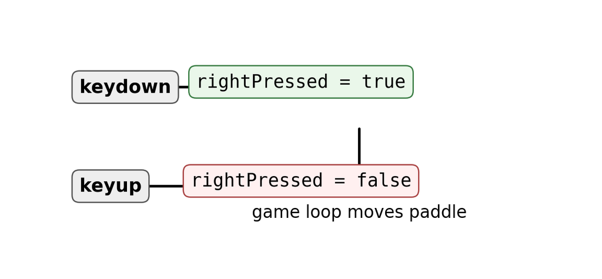

Keyboard events update state; the game loop uses that state.

**Read the picture:** An event changes a remembered value. The loop can then read that value on many frames. The picture uses a right-arrow flag; Pong uses the same idea for the up and down arrows.

```javascript
const keys = {};

window.addEventListener("keydown", e => {
  keys[e.key] = true;
});
window.addEventListener("keyup", e => {
  keys[e.key] = false;
});
```

## 7.2 Move during the update

The game loop checks the state every frame.

```javascript
if (keys["ArrowUp"]) paddleY -= 5;
if (keys["ArrowDown"]) paddleY += 5;
```

## 7.3 Keep the paddle on the screen

`Math.max` and `Math.min` can clamp a value inside a range.

```javascript
paddleY = Math.max(0, paddleY);
paddleY = Math.min(canvas.height - paddleH, paddleY);
```

## 7.4 Paddle collision idea

For a first Pong game, place a vertical paddle on the right. Here, paddleX and paddleY are its top-left coordinates, paddleW and paddleH are its size, and positive dx means the ball is moving right. Test the ball bounding box against the paddle before reversing direction.

```javascript
const overlapsPaddle = (
  ballX + radius >= paddleX &&
  ballX - radius <= paddleX + paddleW &&
  ballY + radius >= paddleY &&
  ballY - radius <= paddleY + paddleH
);
if (dx > 0 && overlapsPaddle) {
  ballX = paddleX - radius;
  dx = -Math.abs(dx);
}
```

## Play Pong in your browser

Save this page as `index.html`, or open `workspace/chapter7-pong/index.html`. Hold the up or down arrow to move the right paddle. The game loop reads the remembered key state every frame, clamps the paddle inside the canvas, and checks whether the ball overlaps it.

COMPLETE EXAMPLE | `index.html`

```html
<!doctype html>
<html lang="en">
<head>
  <meta charset="utf-8">
  <meta name="viewport" content="width=device-width, initial-scale=1">
  <title>Pong Practice</title>
  <style>
    body { margin: 0; min-height: 100vh; display: grid; place-items: center; background: #eaf4ff; font-family: system-ui, sans-serif; color: #17243b; }
    main { padding: 24px; border: 3px solid #17243b; border-radius: 18px; background: white; }
    h1 { margin: 0 0 8px; color: #5d35d5; }
    canvas { display: block; border: 2px solid #17243b; background: #102342; }
    #status { min-height: 1.5em; margin-bottom: 0; }
  </style>
</head>
<body>
  <main>
    <h1>Pong Practice</h1>
    <p>Hold ↑ or ↓ to move the paddle.</p>
    <canvas id="game" width="560" height="320"></canvas>
    <p id="status">Paddle hits: 0</p>
  </main>
  <script>
    const canvas = document.getElementById("game");
    const ctx = canvas.getContext("2d");
    const status = document.getElementById("status");
    const keys = {};
    window.addEventListener("keydown", e => {
      if (e.key === "ArrowUp" || e.key === "ArrowDown") e.preventDefault();
      keys[e.key] = true;
    });
    window.addEventListener("keyup", e => { keys[e.key] = false; });
    window.addEventListener("blur", () => {
      keys.ArrowUp = false;
      keys.ArrowDown = false;
    });

    const paddleX = 530, paddleW = 12, paddleH = 70;
    let paddleY = 125;
    let ballX = 100, ballY = 160;
    let dx = 3, dy = 2;
    const radius = 10;
    let hits = 0;

    function update() {
      if (keys["ArrowUp"]) paddleY -= 5;
      if (keys["ArrowDown"]) paddleY += 5;
      paddleY = Math.max(0, paddleY);
      paddleY = Math.min(canvas.height - paddleH, paddleY);

      ballX += dx;
      ballY += dy;
      if (ballX < radius) dx = Math.abs(dx);
      if (ballY < radius || ballY > canvas.height - radius) dy = -dy;

      const overlapsPaddle = (
        ballX + radius >= paddleX &&
        ballX - radius <= paddleX + paddleW &&
        ballY + radius >= paddleY &&
        ballY - radius <= paddleY + paddleH
      );
      if (dx > 0 && overlapsPaddle) {
        ballX = paddleX - radius;
        dx = -Math.abs(dx);
        hits++;
        status.textContent = "Paddle hits: " + hits;
      }
      if (ballX > canvas.width + radius) {
        ballX = 100;
        ballY = canvas.height / 2;
        dx = Math.abs(dx);
        status.textContent = "Missed! Paddle hits: " + hits;
      }
    }

    function draw() {
      ctx.clearRect(0, 0, canvas.width, canvas.height);
      ctx.fillStyle = "#102342";
      ctx.fillRect(0, 0, canvas.width, canvas.height);
      ctx.fillStyle = "#86d8ff";
      ctx.fillRect(paddleX, paddleY, paddleW, paddleH);
      ctx.beginPath();
      ctx.arc(ballX, ballY, radius, 0, Math.PI * 2);
      ctx.fillStyle = "#ffe48a";
      ctx.fill();
    }

    function loop() {
      update();
      draw();
      requestAnimationFrame(loop);
    }
    draw();
    requestAnimationFrame(loop);
  </script>
</body>
</html>
```

The demonstration pages pause automatic animation and make a known number of updates. The playable `index.html` keeps animating normally.

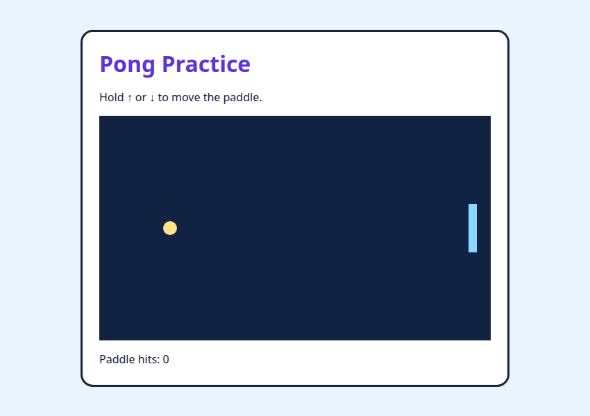

Pong Practice in Chrome before moving the paddle. The ball is left of the right paddle.

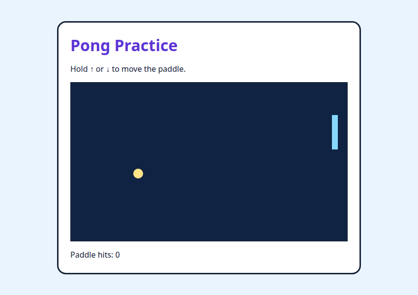

Pong Practice in Chrome after holding the up arrow for twelve updates. The paddle is higher.

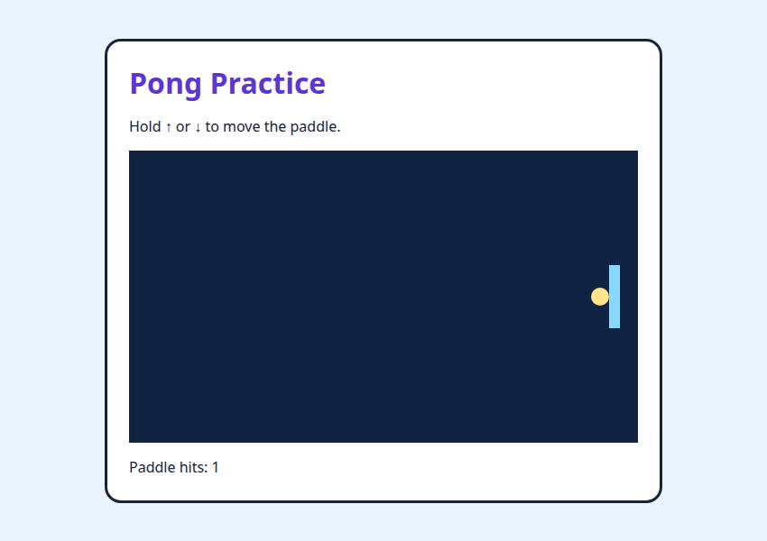

Pong Practice in Chrome after the ball overlaps the paddle. The hit count is one.

**Read the pictures:** A held key leaves `keys["ArrowUp"]` true across several updates, so the paddle keeps moving. When the ball’s bounding box overlaps the paddle and `dx` is positive, the collision code places the ball just left of the paddle and changes `dx` to a negative value. The hit count confirms that the response ran once.

Advanced Study | Input state versus input events

OPTIONAL DEEPER DIVE

An event tells you that something happened once. A state variable remembers whether a key is currently held down. Real-time games usually update state in `keydown`/`keyup` handlers and let the game loop decide how far to move the player each frame.

```javascript
let rightPressed = false;
window.addEventListener("keydown", e => {
  if (e.key === "ArrowRight") rightPressed = true;
});
window.addEventListener("keyup", e => {
  if (e.key === "ArrowRight") rightPressed = false;
});
```

**Events are messages; state is memory.** Holding a key may produce repeated `keydown` events, but we do not use those repeats as a movement clock. A true flag means the loop should keep moving the paddle.

**Focus matters.** A finished game should clear remembered keys when it loses focus, because a key-up event may not arrive where expected. Prevent arrow-key scrolling only while the player is controlling the game, rather than blocking page navigation everywhere.

## 7.5 Level-up challenges

Challenge 1

Add a second paddle controlled by W and S.

Challenge 2

Add a score when the ball passes a paddle.

Challenge 3

Make the ball slightly faster after each paddle hit.

# 8 Manage Many Game Objects

GAME 08 | Breakout

Objects Arrays Loops

How to use the code pieces

The short snippets below explain individual rules. The complete browser example later in this chapter combines them into a playable page.

Your mission

By the end of this chapter, you can:

- store many objects in an array
- use loops to update and draw objects
- remove or mark hit bricks
- understand basic collision tests

The big idea

Breakout has many bricks. We do not want 30 separate variables. Arrays let one variable hold a whole collection of game objects.

## 8.1 Store bricks as objects

Each brick can be an object with position, size, and whether it is still active.

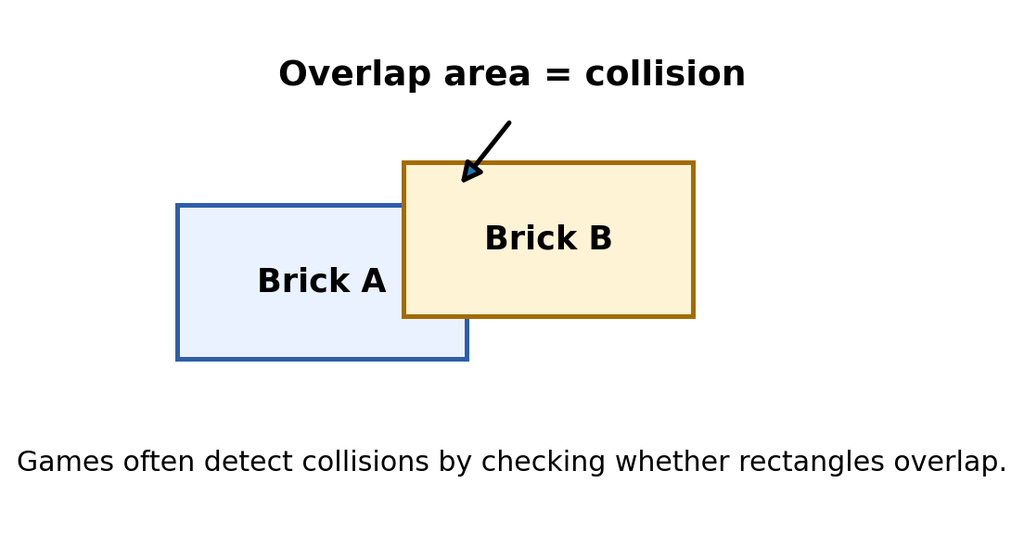

Collision detection asks whether game objects overlap.

**Read the picture:** A collision is not just being close. The shapes overlap horizontally **and** vertically. The picture uses rectangles; the beginner ball test uses a square bounding box around the ball.

```javascript
const bricks = [
  { x: 20, y: 20, w: 60, h: 20, alive: true },
  { x: 90, y: 20, w: 60, h: 20, alive: true },
  { x: 160, y: 20, w: 60, h: 20, alive: true }
];
```

## 8.2 Loop through the array

`for...of` gives us each brick one at a time.

```javascript
for (const brick of bricks) {
  if (brick.alive) {
    ctx.fillRect(brick.x, brick.y, brick.w, brick.h);
  }
}
```

## 8.3 A simple collision test

A ball hits a brick when its position overlaps the brick rectangle. For a beginner version, we can use the ball center plus its radius.

```javascript
function hitsBrick(ballX, ballY, r, brick) {
  return (
    ballX + r > brick.x &&
    ballX - r < brick.x + brick.w &&
    ballY + r > brick.y &&
    ballY - r < brick.y + brick.h
  );
}
```

## 8.4 Change the world after a hit

When a collision happens, mark the brick as no longer alive and reverse the vertical direction of the ball.

```javascript
if (brick.alive && hitsBrick(x, y, radius, brick)) {
  brick.alive = false;
  dy = -dy;
  score++;
}
```

## Play Breakout in your browser

Save this page as `index.html`, or open `workspace/chapter8-breakout/index.html`. Move the paddle with the left and right arrows. Each brick is an object in `bricks`; the game loop visits that array to draw active bricks and test the ball against them.

COMPLETE EXAMPLE | `index.html`

```html
<!doctype html>
<html lang="en">
<head>
  <meta charset="utf-8">
  <meta name="viewport" content="width=device-width, initial-scale=1">
  <title>Breakout Practice</title>
  <style>
    body { margin: 0; min-height: 100vh; display: grid; place-items: center; background: #fff3e8; font-family: system-ui, sans-serif; color: #17243b; }
    main { padding: 24px; border: 3px solid #17243b; border-radius: 18px; background: white; }
    h1 { margin: 0 0 8px; color: #c04a5a; }
    canvas { display: block; border: 2px solid #17243b; background: #17243b; }
    #status { min-height: 1.5em; margin-bottom: 0; }
  </style>
</head>
<body>
  <main>
    <h1>Breakout Practice</h1>
    <p>Hold ← or → to move the paddle and catch the ball.</p>
    <canvas id="game" width="560" height="360"></canvas>
    <p id="status">Bricks cleared: 0</p>
  </main>
  <script>
    const canvas = document.getElementById("game");
    const ctx = canvas.getContext("2d");
    const status = document.getElementById("status");
    const keys = {};
    window.addEventListener("keydown", e => {
      if (e.key === "ArrowLeft" || e.key === "ArrowRight") e.preventDefault();
      keys[e.key] = true;
    });
    window.addEventListener("keyup", e => { keys[e.key] = false; });
    window.addEventListener("blur", () => {
      keys.ArrowLeft = false;
      keys.ArrowRight = false;
    });

    const bricks = [
      { x: 45, y: 40, w: 100, h: 22, alive: true },
      { x: 165, y: 40, w: 100, h: 22, alive: true },
      { x: 285, y: 40, w: 100, h: 22, alive: true },
      { x: 405, y: 40, w: 100, h: 22, alive: true },
      { x: 45, y: 76, w: 100, h: 22, alive: true },
      { x: 165, y: 76, w: 100, h: 22, alive: true },
      { x: 285, y: 76, w: 100, h: 22, alive: true },
      { x: 405, y: 76, w: 100, h: 22, alive: true }
    ];
    let paddleX = 230;
    const paddleY = 330, paddleW = 100, paddleH = 12;
    let x = 280, y = 250, dx = 3, dy = -3;
    const radius = 10;
    let score = 0;

    function hitsBrick(ballX, ballY, r, brick) {
      return (
        ballX + r > brick.x &&
        ballX - r < brick.x + brick.w &&
        ballY + r > brick.y &&
        ballY - r < brick.y + brick.h
      );
    }

    function update() {
      if (keys.ArrowLeft) paddleX -= 6;
      if (keys.ArrowRight) paddleX += 6;
      paddleX = Math.max(0, Math.min(canvas.width - paddleW, paddleX));
      x += dx;
      y += dy;
      if (x < radius || x > canvas.width - radius) dx = -dx;
      if (y < radius) dy = Math.abs(dy);
      if (dy > 0 && y + radius >= paddleY && y - radius <= paddleY + paddleH &&
          x + radius >= paddleX && x - radius <= paddleX + paddleW) {
        y = paddleY - radius;
        dy = -Math.abs(dy);
      }
      for (const brick of bricks) {
        if (brick.alive && hitsBrick(x, y, radius, brick)) {
          brick.alive = false;
          dy = -dy;
          score++;
          status.textContent = "Bricks cleared: " + score;
          break;
        }
      }
      if (y > canvas.height + radius) {
        x = canvas.width / 2;
        y = 250;
        dy = -3;
        status.textContent = "Try again! Bricks cleared: " + score;
      }
    }

    function draw() {
      ctx.clearRect(0, 0, canvas.width, canvas.height);
      ctx.fillStyle = "#17243b";
      ctx.fillRect(0, 0, canvas.width, canvas.height);
      for (const brick of bricks) {
        if (brick.alive) {
          ctx.fillStyle = brick.y === 40 ? "#f899b5" : "#ffe48a";
          ctx.fillRect(brick.x, brick.y, brick.w, brick.h);
        }
      }
      ctx.fillStyle = "#8ce3ff";
      ctx.fillRect(paddleX, paddleY, paddleW, paddleH);
      ctx.beginPath();
      ctx.arc(x, y, radius, 0, Math.PI * 2);
      ctx.fillStyle = "white";
      ctx.fill();
    }

    function loop() {
      update();
      draw();
      requestAnimationFrame(loop);
    }
    draw();
    requestAnimationFrame(loop);
  </script>
</body>
</html>
```

The demonstration pages pause automatic animation and place the ball for one or three known collisions. The playable `index.html` keeps animating normally.

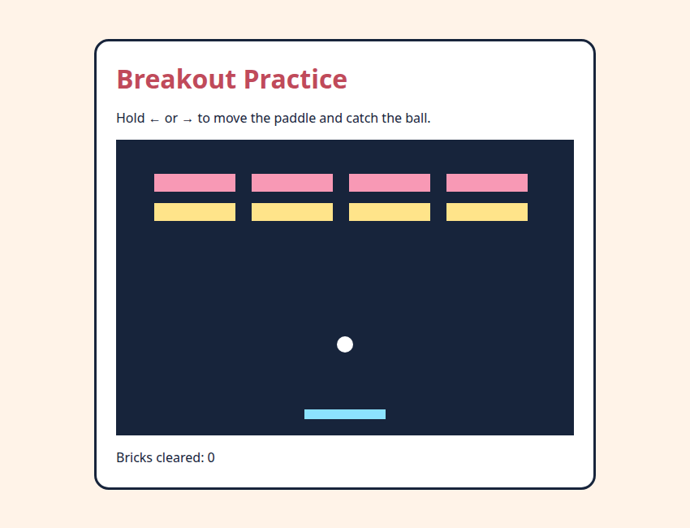

Breakout Practice in Chrome before a brick is hit. Eight colored bricks are visible.

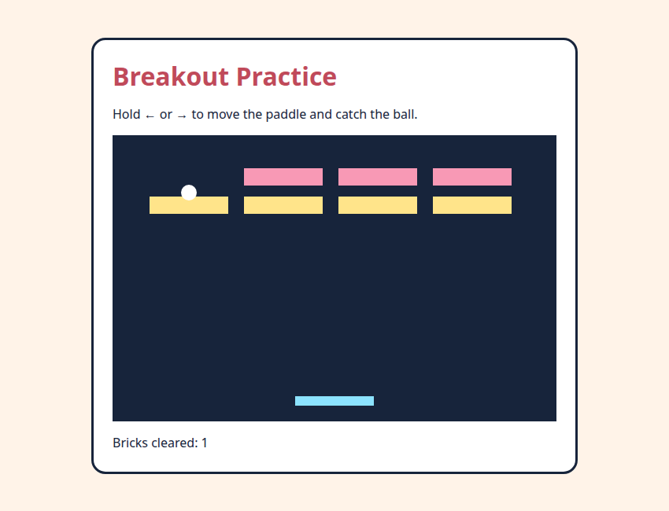

Breakout Practice in Chrome after one brick is hit. One brick disappears and the score is one.

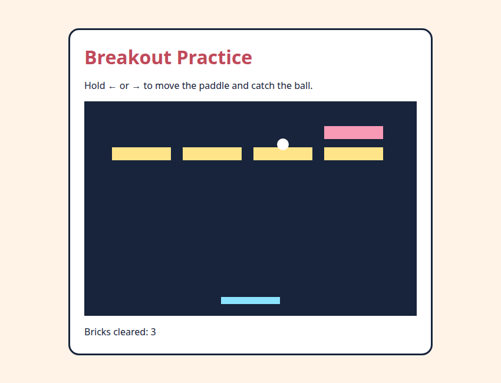

Breakout Practice in Chrome after three brick hits. Three bricks disappear and the score is three.

**Read the pictures:** A collision makes `brick.alive` false, so the drawing loop skips that object on later frames. The brick stays in the array, but it is no longer visible or hittable. `score++` records each hit, and `break` stops this update after one collision so the ball reverses only once.

Advanced Study | Objects, arrays, and collision logic

OPTIONAL DEEPER DIVE

An object groups properties that belong to one game object. An array stores many objects in order. A common rectangle collision test checks whether one rectangle is not completely left, right, above, or below the other. Larger games often separate `update()`, `draw()`, and collision functions.

```javascript
const brick = { x: 40, y: 20, w: 60, h: 20, alive: true };
bricks.push(brick);
```

**Each object is one brick; the array is the collection.** `brick.alive = false` changes a property on that brick. A `for...of` loop can visit the collection when checking collisions and when drawing.

**Know the approximation.** `hitsBrick` checks the square around the ball against the brick. At a corner, those squares can overlap before the circle itself touches. A fast ball can also jump past a thin brick between frames.

**One hit, one response.** Avoid reversing the ball repeatedly for several bricks in one update. A simple first approach is to stop checking after the first detected hit.

## 8.5 Level-up challenges

Challenge 1

Create the brick array with nested loops instead of typing each brick.

Challenge 2

Give some bricks two hit points.

Challenge 3

Add a win condition when every brick is gone.

# 9 Build a World on a Grid

GAME 09 | Snake

Grid cells Arrays Game state

How to use the code pieces

The short snippets below explain individual rules. The complete browser example later in this chapter combines them into a playable page.

Your mission

By the end of this chapter, you can:

- represent positions as grid cells
- store the snake as an array
- update the world one step at a time
- detect self and wall collisions

The big idea

Snake becomes easier when the world is a grid. Instead of moving by tiny pixels, the snake moves one cell at a time.

## 9.1 A snake is a list of body cells

The first item can be the head. Each cell stores x and y coordinates.

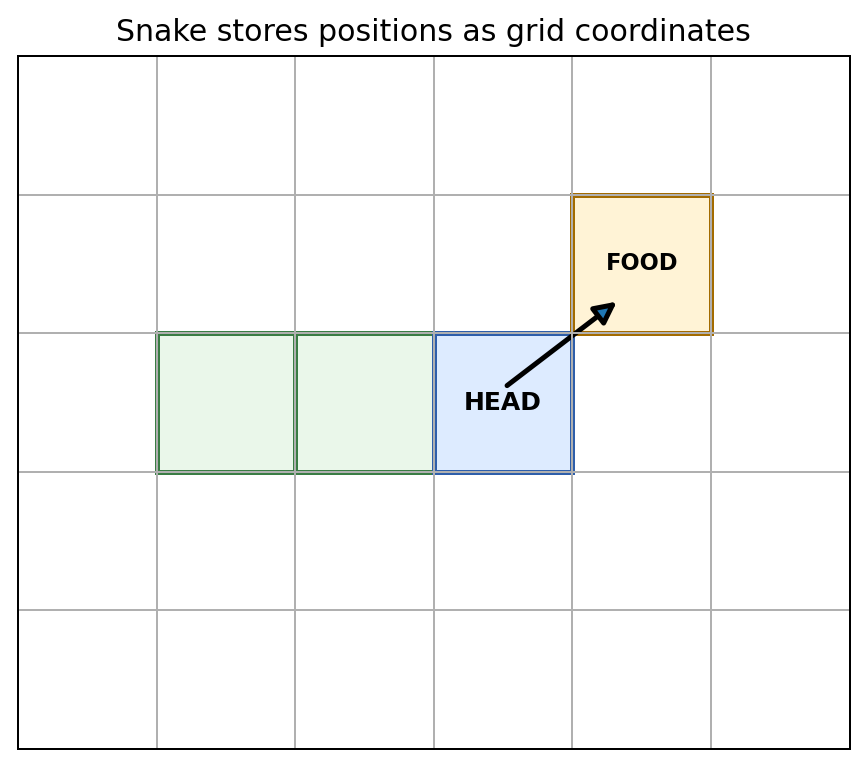

A grid game stores positions as x/y cells.

**Read the picture:** Each square is one cell, not one screen pixel. The head is the first item in the body array. The arrow points toward food; it does not allow a diagonal move. Move one horizontal or vertical cell per step.

```javascript
let snake = [
  { x: 5, y: 5 },
  { x: 4, y: 5 },
  { x: 3, y: 5 }
];
```

## 9.2 Move by creating a new head

We calculate a new head from the old head and the current direction. Then `unshift` adds it to the front. `pop` removes the last tail cell.

```javascript
const head = snake[0];
const newHead = { x: head.x + dx, y: head.y + dy };
snake.unshift(newHead);
snake.pop();
```

## 9.3 Grow when food is eaten

If the head lands on food, do not remove the tail that step. The snake becomes one cell longer.

```javascript
if (newHead.x === food.x && newHead.y === food.y) {
  score++;
  placeFood();
} else {
  snake.pop();
}
```

## 9.4 Prevent instant reverse direction

If the snake is moving right, switching directly to left would make the head collide with the body. Check the old direction before accepting the new one.

```javascript
if (e.key === "ArrowLeft" && dx !== 1) {
  dx = -1;
  dy = 0;
}
```